# Tarea 3: clasificación y devianza

FG

8/28/2018

### Instrucciones

En este ejercicio tienes que completar algunas líneas de código para contestar las preguntas

Consideramos los datos que vimos en clase, donde *diabetes* es la variable indicadora si la persona tiene o no diabetes:

```r
library(tidyverse)
diabetes_ent <- as_data_frame(MASS::Pima.tr)
diabetes_pr <- as_data_frame(MASS::Pima.te)
datos_ent <- diabetes_ent %>%
  mutate(diabetes = as.numeric(type == "Yes")) %>%
  select(diabetes, glu)
set.seed(886)
# Usamos una muestra chica de prueba para examinar los resultados
datos_pr <- diabetes_pr %>%
  mutate(diabetes = as.numeric(type == "Yes")) %>%
  select(diabetes, glu) %>%
  sample_n(10)
datos_ent
```

```
## # A tibble: 200 x 2
##    diabetes   glu
##       <dbl> <int>
##  1        0    86
##  2        1   195
##  3        0    77
##  4        0   165
##  5        0   107
##  6        1    97
##  7        0    83
##  8        0   193
##  9        0   142
## 10        1   128
## # ... with 190 more rows
```

Trabajaremos con una muestra chica de prueba para entender los resultados:

```r
datos_pr <- datos_pr %>% arrange(glu)
datos_pr
```

```
## # A tibble: 10 x 2
##    diabetes   glu
##       <dbl> <int>
##  1        0    99
##  2        0   100
##  3        0   112
##  4        0   123
##  5        0   129
##  6        0   142
##  7        1   171
##  8        1   186
##  9        1   189
## 10        1   193
```

### Preguntas

1. (Modelo sin covariables) Si no tuviéramos covariables, ¿cómo estimamos la probabilidad de clase $p_1 = P(G = 1)$ donde G=diabetes? Usa la muestra de entrenamiento para hacer esta estimación.

```r
# termina esta línea
p_1_simple <- mean(datos_ent$diabetes)
```

2. Agregar la probabilidad estimada a la tabla de datos de prueba y examina la tabla:

```r
datos_pr$p_1_simple <- p_1_simple
datos_pr
```

```
## # A tibble: 10 x 3
##    diabetes   glu p_1_simple
##       <dbl> <int>      <dbl>
##  1        0    99       0.34
##  2        0   100       0.34
##  3        0   112       0.34
##  4        0   123       0.34
##  5        0   129       0.34
##  6        0   142       0.34
##  7        1   171       0.34
##  8        1   186       0.34
##  9        1   189       0.34
## 10        1   193       0.34
```

2. **Calcula la devianza de prueba para cada caso** según el modelo simple (el error de cada caso de prueba). Examina la tabla resultante:

```r
# explica por qué esta es la fórmula correcta:
devianza <- function(g, p_1){
  -2*(g * log(p_1) + (1 - g) * log(1 - p_1))
}
# termina esta línea
datos_pr$devianza_simple <- devianza(datos_pr$diabetes,datos_pr$p_1_simple)
  datos_pr
```

```
## # A tibble: 10 x 4
##    diabetes   glu p_1_simple devianza_simple
##       <dbl> <int>      <dbl>           <dbl>
##  1        0    99       0.34           0.831
##  2        0   100       0.34           0.831
##  3        0   112       0.34           0.831
##  4        0   123       0.34           0.831
##  5        0   129       0.34           0.831
##  6        0   142       0.34           0.831
##  7        1   171       0.34           2.16
##  8        1   186       0.34           2.16
##  9        1   189       0.34           2.16
## 10        1   193       0.34           2.16
```

3. **Calcula la devianza promedio** de prueba para este modelo simple:

```r
# termina esta línea
mean(datos_pr$devianza_simple)
```

```
## [1] 1.361666
```

```r
# Para probabilidad p_1=0.75
datos_pr$p_1_simple_075      <- 0.75
datos_pr$devianza_simple_075 <- devianza(datos_pr$diabetes,datos_pr$p_1_simple_075)
mean(datos_pr$devianza_simple_075)
```

```
## [1] 1.893699
```

```r
# Para probabilidad p_1=0.5
datos_pr$p_1_simple_050      <- 0.50
datos_pr$devianza_simple_050 <- devianza(datos_pr$diabetes,datos_pr$p_1_simple_050)
mean(datos_pr$devianza_simple_050)
```

```
## [1] 1.386294
```

```r
glimpse(round(datos_pr,2))
```

```
## Observations: 10
## Variables: 8
## $ diabetes            <dbl> 0, 0, 0, 0, 0, 0, 1, 1, 1, 1
## $ glu                 <dbl> 99, 100, 112, 123, 129, 142, 171, 186, 189...
## $ p_1_simple          <dbl> 0.34, 0.34, 0.34, 0.34, 0.34, 0.34, 0.34, ...
## $ devianza_simple     <dbl> 0.83, 0.83, 0.83, 0.83, 0.83, 0.83, 2.16, ...
## $ p_1_simple_075      <dbl> 0.75, 0.75, 0.75, 0.75, 0.75, 0.75, 0.75, ...
## $ devianza_simple_075 <dbl> 2.77, 2.77, 2.77, 2.77, 2.77, 2.77, 0.58, ...
## $ p_1_simple_050      <dbl> 0.5, 0.5, 0.5, 0.5, 0.5, 0.5, 0.5, 0.5, 0....
## $ devianza_simple_050 <dbl> 1.39, 1.39, 1.39, 1.39, 1.39, 1.39, 1.39, ...
```

En el caso en que se asigna la probabilidad de diabetes en 0.75, la devianza para los casos con diabetes disminuye, sin embargo para los que no tienen diabetes la devianza aumenta y en la muestra de prueba hay menos casos de diabetes, por lo que la devianza promedio es mayor. Si la probabilidad de diabetes es 0.5, entonces la devianza es la misma en todos los casos, por que el 0.5 está a la misma distancia del 0 que del 1 y el error es el mismo para todos. El mejor caso es utilizar la probabilidad obtenida con la muestra de entrenamiento que es 0.34.

5. Ahora construimos un modelo de una sola variable (glucosa) que no nos va a servir. Intentamos usaremos regresión lineal:

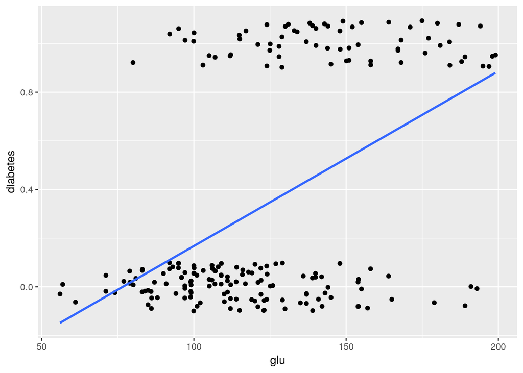

```r
ggplot(datos_ent, aes(x = glu, y = diabetes)) +
  geom_jitter(width=0.1, height=0.1) + geom_smooth(se = FALSE, method = "lm")
```

**¿Qué defecto ves en este modelo? El problema es que para valores de glucosa menores a 76.656 (más error de redondeo) la función da valores menores a cero y para valores de glucosa mayores 215.8155 (más error de redondeo) la función da valores mayores a uno. ¿Es posible calcular la devianza de este modelo? No ¿Por qué sí o no? Por que el logaritmo no está definido para valores de $(-\infty,0])$, por lo que si se obtiene un valor $c< 0$ no se puede evaluar $log(c)$, mientras que si se obtiene $c>1$ no se puede evaluar $log(1-c)$, por que $1-c<0$.

Demuestra que este modelo simple no nos da probabilidades de clase evaluando la predicción en algún valor**:

```r
# escoge un valor problemático para este modelo problemático
valor_malo <- 56
  #
mod_lineal <- lm(diabetes ~ glu, data = datos_ent)
predict(mod_lineal, data_frame(glu = valor_malo))
```

```
##          1
## -0.1484335
```

6. Consideremos una mejora usando k-vecinos más cercanos:

```r
library(kknn)
set.seed(464833)
# escoge entre 50 o 60 k-vecinos más cercanos
k <- floor(runif(1,50,60))
k
```

```
## [1] 56
```

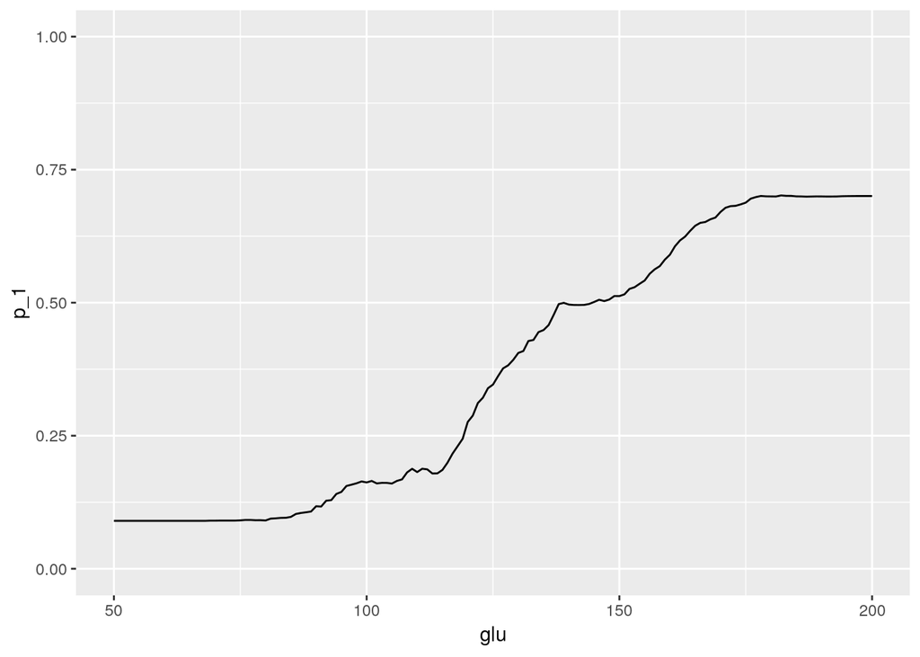

```r
graf_datos <- data_frame(glu = seq(50, 200))
mod_vmc <- kknn(diabetes ~ glu, k = k, train = datos_ent,
                test = graf_datos)
graf_datos$p_1 <- mod_vmc$fitted.values
ggplot(graf_datos, aes(x = glu, y = p_1)) + geom_line() + ylim(c(0,1))
```

**Explica por qué este modelo es más apropiado para este problema de clasificación** ¿Nos da probabilidades? Este modelo hace un promedio de los individuos más cercanos, como los valores de los individuos ceranos son cero o uno el promedio será un valor entre cero y uno, por lo que podrían verse como probabilidades.

7. Agregar la probabilidad estimada según el modelo del inciso anterior a la misma tabla de datos de prueba. Examina la tabla:

```r
preds_vmc <- kknn(diabetes ~ glu, k = k, train = datos_ent, test = datos_pr)
datos_pr$p_1_vmc <- predict(preds_vmc)
glimpse(round(datos_pr,2))
```

```
## Observations: 10
## Variables: 9
## $ diabetes            <dbl> 0, 0, 0, 0, 0, 0, 1, 1, 1, 1
## $ glu                 <dbl> 99, 100, 112, 123, 129, 142, 171, 186, 189...
## $ p_1_simple          <dbl> 0.34, 0.34, 0.34, 0.34, 0.34, 0.34, 0.34, ...
## $ devianza_simple     <dbl> 0.83, 0.83, 0.83, 0.83, 0.83, 0.83, 2.16, ...
## $ p_1_simple_075      <dbl> 0.75, 0.75, 0.75, 0.75, 0.75, 0.75, 0.75, ...
## $ devianza_simple_075 <dbl> 2.77, 2.77, 2.77, 2.77, 2.77, 2.77, 0.58, ...
## $ p_1_simple_050      <dbl> 0.5, 0.5, 0.5, 0.5, 0.5, 0.5, 0.5, 0.5, 0....
## $ devianza_simple_050 <dbl> 1.39, 1.39, 1.39, 1.39, 1.39, 1.39, 1.39, ...
## $ p_1_vmc             <dbl> 0.16, 0.16, 0.19, 0.32, 0.39, 0.50, 0.68, ...
```

Examinando la tabla, ¿por qué piensas que este nuevo modelo que usa una covariable puede tener menor devianza? (examina la varaible diabetes y la probabilidad p_1_vmc) Por que existe algún tipo de relación entre las variables glucosa y diabetes. Esto se ve reflejado en el promedio de casos con diabetes por nivel de glucosa y por lo tanto en el resultado de k vecinos más cercanos.

8. Calcula la devianza para cada caso de prueba según el modelo de vecinos más cercanos, y agrega a la tabla. ¿Cúales son los errores más grandes y más chicos con este nuevo modelo? Explica los casos de devianza grande.

```r
# termina la siguiente línea
datos_pr$devianza_vmc <- devianza(datos_pr$diabetes,datos_pr$p_1_vmc)
  datos_pr$devianza_vmc
```

```
##  [1] 0.3583484 0.3539393 0.4133524 0.7755311 0.9968291 1.3688100 0.7760682
##  [8] 0.7144272 0.7142319 0.7145249
```

9. Calcula la devianza promedio de prueba para el modelo de vecinos más cercanos

```r
# escribe aquí la línea de código que calcula la devianza promedio
mean(datos_pr$devianza_vmc)
```

```
## [1] 0.7186062
```

```r
mean(datos_pr$devianza_simple)
```

```
## [1] 1.361666
```

10. Aunque la muestra de prueba es chica, ¿cuál es el mejor modelo según la devianza de prueba, el simple o el de vecinos más cercanos?

Según la devianza promedio el mejor modelo es el de k vecinos.